# Supplementary figure: A priori PBPK prediction fold errors

Author

NAMLink

# Purpose

This supplementary script creates one six-panel tornado plot from the complete scenario-level results embedded in `03_Process_Sims_Outputs.html`. It does not rerun a PBPK simulation or recalculate a PK endpoint.

The rows compare monkey and human predictions. The columns show AUC0-tlast, Cmax, and clearance. Each horizontal bar represents one molecule-dose scenario and begins at a fold error of 1. Underprediction extends to the left and overprediction extends to the right on a base-2 logarithmic scale. Clearance scenarios that fail the observed AUCinf extrapolation criterion are shown as `Not evaluable` rather than as fold-error bars.

```r
rm(list = ls())

suppressPackageStartupMessages({
  library(dplyr)
  library(ggplot2)
  library(knitr)
  library(purrr)
  library(readr)
  library(rvest)
  library(scales)
  library(tibble)
  library(tidyr)
  library(xml2)
})

find_project_root <- function(start = getwd()) {
  current <- normalizePath(start, winslash = "/", mustWork = TRUE)
  repeat {
    required <- c(
      file.path(current, "01_Models"),
      file.path(current, "02_APriori_PBPK_Workflow")
    )
    if (all(dir.exists(required))) return(current)
    parent <- dirname(current)
    if (identical(parent, current)) {
      stop("Could not locate the PBPK_mAb_NAM_Tutorial project root.")
    }
    current <- parent
  }
}

PROJECT_ROOT <- find_project_root()
WORKFLOW_DIR <- file.path(PROJECT_ROOT, "02_APriori_PBPK_Workflow")
SCRIPT_DIR <- file.path(WORKFLOW_DIR, "Scripts")
OUTPUT_DIR <- file.path(WORKFLOW_DIR, "SimsOutputs")
FIGURE_DIR <- file.path(OUTPUT_DIR, "Figures")
TABLE_DIR <- file.path(OUTPUT_DIR, "Tables")

walk(
  c(OUTPUT_DIR, FIGURE_DIR, TABLE_DIR),
  dir.create,
  recursive = TRUE,
  showWarnings = FALSE
)

INPUT_HTML <- file.path(SCRIPT_DIR, "03_Process_Sims_Outputs.html")
OUTPUT_FIGURE <- file.path(
  FIGURE_DIR,
  "Supplement_Fold_Error_Tornado_Monkey_Human.png"
)
OUTPUT_TABLE <- file.path(
  TABLE_DIR,
  "Supplement_Fold_Error_Tornado_Data.csv"
)

if (!file.exists(INPUT_HTML)) {
  stop(
    "The completed Step 3 HTML report is missing: ", INPUT_HTML,
    ". Render 03_Process_Sims_Outputs.qmd before running this supplement."
  )
}

SPECIES_LEVELS <- c("Monkey", "Human")
METRIC_LEVELS <- c("AUC0-tlast", "Cmax", "Clearance")
METRIC_COLUMNS <- c(
  `AUC0-tlast` = "FE_AUC0_tlast",
  Cmax = "FE_Cmax",
  Clearance = "FE_Clearance"
)

SPECIES_COLORS <- c(
  Monkey = "#79B8D4",
  Human = "#79B8D4"
)
```

# Step 1 Extract the completed scenario-level results

The source report contains a table captioned *Complete observed and predicted scenario-level PK metrics*. The script selects that table by its caption rather than by table position, then validates the columns used in the figure.

```r
html_document <- read_html(INPUT_HTML)
html_tables <- html_elements(html_document, "table")
table_captions <- map_chr(html_tables, function(table_node) {
  caption_node <- html_element(table_node, "caption")
  if (inherits(caption_node, "xml_missing")) "" else html_text2(caption_node)
})

source_caption <- "Complete observed and predicted scenario-level PK metrics"
source_table_index <- which(table_captions == source_caption)

if (length(source_table_index) != 1L) {
  stop(
    "Expected exactly one HTML table captioned '", source_caption,
    "'; found ", length(source_table_index), "."
  )
}

scenario_metrics <- html_table(
  html_tables[[source_table_index]],
  fill = TRUE,
  convert = TRUE
) |>
  as_tibble()

required_columns <- c(
  "Molecule", "Species", "Dose", unname(METRIC_COLUMNS)
)
missing_columns <- setdiff(required_columns, names(scenario_metrics))
if (length(missing_columns) > 0L) {
  stop(
    "The source table is missing required columns: ",
    paste(missing_columns, collapse = ", "), "."
  )
}

scenario_metrics <- scenario_metrics |>
  transmute(
    Molecule = as.character(.data$Molecule),
    Species = as.character(.data$Species),
    Dose_mg_kg = as.numeric(.data$Dose),
    FE_AUC0_tlast = as.numeric(.data$FE_AUC0_tlast),
    FE_Cmax = as.numeric(.data$FE_Cmax),
    FE_Clearance = as.numeric(.data$FE_Clearance)
  )

if (!setequal(unique(scenario_metrics$Species), SPECIES_LEVELS)) {
  stop("The source table must contain both Monkey and Human results only.")
}

duplicate_scenarios <- scenario_metrics |>
  count(
    .data$Species, .data$Molecule, .data$Dose_mg_kg,
    name = "Records"
  ) |>
  filter(.data$Records != 1L)

if (nrow(duplicate_scenarios) > 0L) {
  stop("The source table contains duplicate species-molecule-dose records.")
}

tibble(
  Source = INPUT_HTML,
  Source_table = source_caption,
  Scenarios = nrow(scenario_metrics),
  Monkey_scenarios = sum(scenario_metrics$Species == "Monkey"),
  Human_scenarios = sum(scenario_metrics$Species == "Human")
) |>
  kable(caption = "Validated source for the supplementary figure")
```

Validated source for the supplementary figure

| Source | Source_table | Scenarios | Monkey_scenarios | Human_scenarios |
| --- | --- | --- | --- | --- |
| /work/02_APriori_PBPK_Workflow/Scripts/03_Process_Sims_Outputs.html | Complete observed and predicted scenario-level PK metrics | 44 | 14 | 30 |

# Step 2 Prepare directional fold errors

Fold error is defined as predicted divided by observed. The plotted coordinate is `log2(fold error)`, so 0.5 and 2 are equally distant from the reference value of 1. Labels retain the fold error on its original scale.

```r
format_dose <- function(x) {
  format(
    x,
    trim = TRUE,
    scientific = FALSE,
    drop0trailing = TRUE
  )
}

fold_error_data <- scenario_metrics |>
  pivot_longer(
    cols = all_of(unname(METRIC_COLUMNS)),
    names_to = "Metric_column",
    values_to = "Fold_error"
  ) |>
  mutate(
    Metric = names(METRIC_COLUMNS)[
      match(.data$Metric_column, METRIC_COLUMNS)
    ],
    Species = factor(.data$Species, levels = SPECIES_LEVELS),
    Metric = factor(.data$Metric, levels = METRIC_LEVELS),
    Dose_label = format_dose(.data$Dose_mg_kg),
    Scenario_label = paste0(
      .data$Molecule, "  |  ", .data$Dose_label, " mg/kg"
    ),
    Scenario_key = paste(.data$Species, .data$Scenario_label, sep = "::"),
    Log2_fold_error = log2(.data$Fold_error),
    Evaluation_status = if_else(
      is.finite(.data$Fold_error) & .data$Fold_error > 0,
      "Evaluated",
      "Not evaluable"
    ),
    Fold_error_label = number(
      .data$Fold_error,
      accuracy = 0.01,
      trim = TRUE
    )
  )

invalid_fold_errors <- fold_error_data |>
  filter(
    .data$Evaluation_status == "Not evaluable",
    .data$Metric != "Clearance"
  )
if (nrow(invalid_fold_errors) > 0L) {
  stop(
    "Only clearance may be not evaluable; found ",
    nrow(invalid_fold_errors), " invalid non-clearance values."
  )
}

scenario_levels <- fold_error_data |>
  distinct(
    .data$Species, .data$Molecule, .data$Dose_mg_kg,
    .data$Scenario_key
  ) |>
  arrange(
    .data$Species,
    .data$Molecule,
    .data$Dose_mg_kg
  ) |>
  pull(.data$Scenario_key)

fold_error_data <- fold_error_data |>
  mutate(
    Scenario_key = factor(
      .data$Scenario_key,
      levels = rev(scenario_levels)
    ),
    Label_x = .data$Log2_fold_error +
      if_else(.data$Log2_fold_error >= 0, 0.08, -0.08),
    Label_hjust = if_else(.data$Log2_fold_error >= 0, 0, 1)
  )

evaluable_fold_error_data <- fold_error_data |>
  filter(.data$Evaluation_status == "Evaluated")
not_evaluable_data <- fold_error_data |>
  filter(.data$Evaluation_status == "Not evaluable")

write_csv(
  fold_error_data |>
    transmute(
      Species = as.character(.data$Species),
      Metric = as.character(.data$Metric),
      .data$Molecule,
      .data$Dose_mg_kg,
      .data$Fold_error,
      .data$Log2_fold_error,
      .data$Evaluation_status
    ),
  OUTPUT_TABLE
)
```

# Step 3 Create the six-panel tornado plot

```r
maximum_log2_error <- max(abs(evaluable_fold_error_data$Log2_fold_error))
log2_limit <- max(1, ceiling(maximum_log2_error))
log2_breaks <- seq(-log2_limit, log2_limit, by = 1)
fold_break_labels <- number(
  2^log2_breaks,
  accuracy = 0.001,
  trim = TRUE
)

tornado_plot <- ggplot(
  evaluable_fold_error_data,
  aes(
    x = .data$Log2_fold_error,
    y = .data$Scenario_key,
    fill = .data$Species
  )
) +
  annotate(
    "rect",
    xmin = log2(0.5),
    xmax = log2(2),
    ymin = -Inf,
    ymax = Inf,
    fill = "#D7EAF3",
    alpha = 0.52
  ) +
  geom_vline(
    xintercept = log2(c(0.5, 2)),
    color = "#5F7F8E",
    linewidth = 0.65,
    linetype = "22"
  ) +
  geom_vline(xintercept = 0, color = "#222222", linewidth = 0.8) +
  geom_col(
    width = 0.70,
    color = "white",
    linewidth = 0.22,
    alpha = 0.92
  ) +
  geom_text(
    aes(
      x = .data$Label_x,
      label = .data$Fold_error_label,
      hjust = .data$Label_hjust
    ),
    size = 3.15,
    color = "#202020"
  ) +
  geom_text(
    data = not_evaluable_data,
    aes(x = 0, y = .data$Scenario_key, label = "Not evaluable"),
    inherit.aes = FALSE,
    size = 3.0,
    color = "#7A1F1F",
    fontface = "italic"
  ) +
  facet_grid(
    rows = vars(.data$Species),
    cols = vars(.data$Metric),
    scales = "free_y",
    space = "free_y"
  ) +
  scale_fill_manual(values = SPECIES_COLORS, guide = "none") +
  scale_x_continuous(
    breaks = log2_breaks,
    labels = fold_break_labels,
    expand = expansion(mult = 0)
  ) +
  scale_y_discrete(
    labels = function(x) sub("^[^:]+::", "", x),
    drop = TRUE
  ) +
  coord_cartesian(
    xlim = c(-log2_limit - 0.45, log2_limit + 0.45),
    clip = "off"
  ) +
  labs(
    title = "A priori PBPK prediction fold errors in monkeys and humans",
    subtitle = paste(
      "Predicted / observed; bars begin at 1.",
      "Shading and dashed lines show the 0.5- to 2-fold interval."
    ),
    x = "Fold error (base-2 logarithmic scale)",
    y = NULL
  ) +
  theme_bw(base_size = 13) +
  theme(
    text = element_text(color = "#202020"),
    plot.title = element_text(
      face = "bold",
      size = 22,
      margin = margin(b = 7)
    ),
    plot.subtitle = element_text(
      size = 14,
      color = "#444444",
      margin = margin(b = 13)
    ),
    strip.background = element_rect(
      fill = "grey90",
      color = "grey45",
      linewidth = 0.65
    ),
    strip.text.x = element_text(
      face = "bold",
      size = 15,
      margin = margin(8, 5, 8, 5)
    ),
    strip.text.y = element_text(
      face = "bold",
      size = 15,
      margin = margin(8, 7, 8, 7)
    ),
    axis.text.x = element_text(size = 11.5, color = "#303030"),
    axis.text.y = element_text(size = 10.5, color = "#303030"),
    axis.title.x = element_text(
      face = "bold",
      size = 14,
      margin = margin(t = 10)
    ),
    panel.grid.major.x = element_line(color = "#DFE9EE", linewidth = 0.45),
    panel.grid.major.y = element_line(color = "#EDF3F6", linewidth = 0.35),
    panel.grid.minor = element_blank(),
    panel.spacing.x = grid::unit(0.55, "lines"),
    panel.spacing.y = grid::unit(0.55, "lines"),
    panel.border = element_rect(color = "#607D8B", linewidth = 0.65),
    plot.margin = margin(15, 28, 15, 15)
  )

png_device <- if (requireNamespace("ragg", quietly = TRUE)) {
  ragg::agg_png
} else {
  "png"
}
```

```
systemfonts and textshaping have been compiled with different versions of Freetype. Because of this, textshaping will not use the font cache provided by systemfonts
```

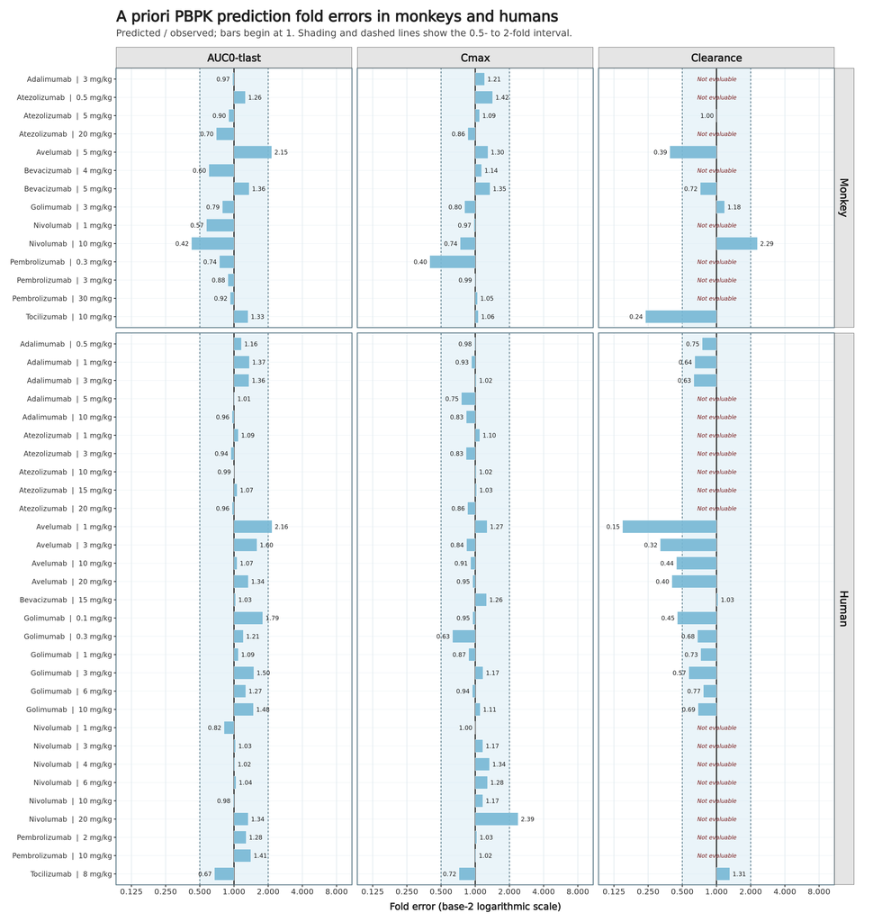

Fold-errors from PBPK model predictions without calibration with in vivo PK data for monkeys and humans. Fold error equals predicted divided by observed; bars extend from 1 on a base-2 logarithmic scale, and the shaded region and dashed lines indicate the 0.5- to 2-fold interval.

```r
ggsave(
  filename = OUTPUT_FIGURE,
  plot = tornado_plot,
  device = png_device,
  width = 18,
  height = 19,
  units = "in",
  dpi = 320,
  bg = "white",
  limitsize = FALSE
)

tornado_plot
```

# Output record

```r
tibble(
  Output = c(
    "Six-panel fold-error tornado figure",
    "Plotting data extracted from the completed HTML"
  ),
  Path = c(OUTPUT_FIGURE, OUTPUT_TABLE)
) |>
  kable(caption = "Supplementary figure outputs")
```

Supplementary figure outputs

| Output | Path |
| --- | --- |
| Six-panel fold-error tornado figure | /work/02_APriori_PBPK_Workflow/SimsOutputs/Figures/Supplement_Fold_Error_Tornado_Monkey_Human.png |
| Plotting data extracted from the completed HTML | /work/02_APriori_PBPK_Workflow/SimsOutputs/Tables/Supplement_Fold_Error_Tornado_Data.csv |